[figure not shown]

# PyData Southampton News, March 2025

### 14th Meetup, hosted by Carnival UK

### @PyDataSoton

# PyData Code of Conduct

### https://pydata.org/code-of-conduct/

[interactive chart not shown]

# NumFOCUS

- US-based charity in support of open-source scientific computing
- Financial and admin support for many open-source projects
- Support for many community events
- https://numfocus.org

[interactive chart not shown]

# PyData

- Educational program by NumFOCUS
- A global community
- 245 groups across 80 countries world-wide
- 253,914+ users world-wide (+23,000 per year!)

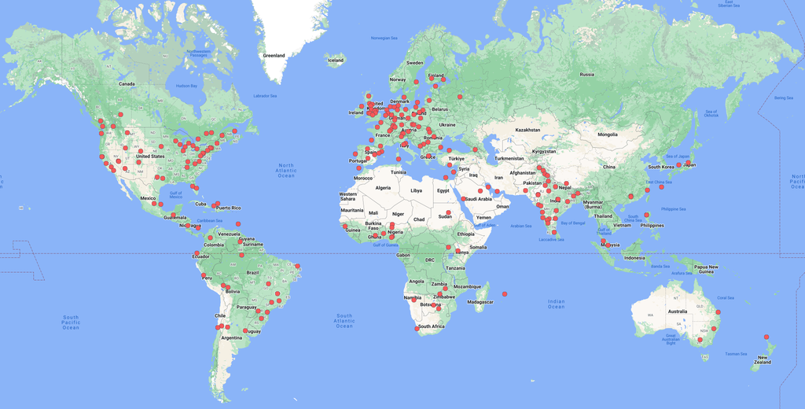

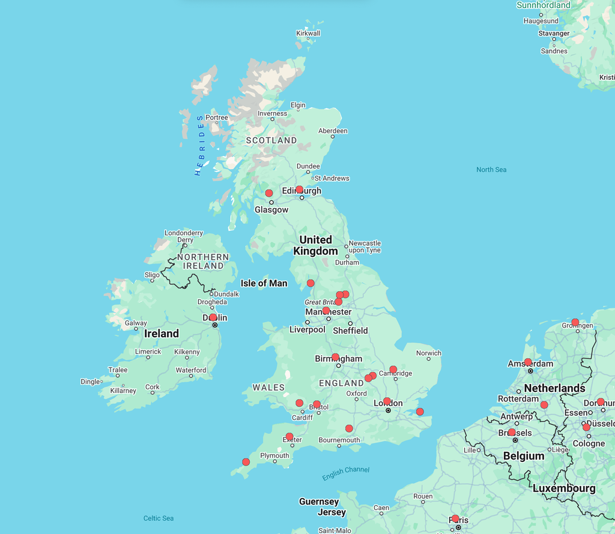

# PyData Southampton

- 563 members (~20 per month! Tell a friend! Submit a talk! Always need a ⚡)
- Monthly meetup
- All run by volunteers
- Propose a Talk: https://bit.ly/pydataSoton-talks

[figure not shown]

1. The operating company for P&O Cruises & Cunard; no one knows cruising like Carnival UK!
2. Sponsors **PyData Southampton** ❤️❤️❤️

# Upcoming Conferences

### Courtesy of https://pythondeadlin.es/

#### 🇺🇸 April 18-19 2025 - PyData Virginia 2025 🚨 CFP closed 🚨

#### 🌎 April 23-25 2025 - PyCon DE & PyData 2025 🚨 CFP closed 🚨

#### 🇬🇧 June 06-08 2025 - PyData London 2025 🚨 CFP closed 🚨

#### 🇬🇧 September 19-22 2025 - PyCon UK 2025 🚨 CFP open until 11 May 🚨

[interactive chart not shown]

[figure not shown]

# Tonight's Schedule

#### 18:30 Doors open

#### 19:00 Talks start ⬅️ **YOU ARE HERE**

#### 19:15 Talk #1 + Q&A

#### 19:45 Break 🥂

#### 20:00 Talk #2 + Q&A

#### 20:30 ⚡ Lightning Talks ⚡ + 📣 Community Announcements 📣

#### 20:45 to 21:00 We're done 🔜 All Bar One 🍻

### 1️⃣ How to Hack an Agent - or not - Thomas Fraunholz

LLMs are not safe. And it's not because of their ability to hallucinate while working. LLMs can be manipulated. So far, the known security mechanisms have not really proven to be solid. For example, if you use jailbreaks correctly, you can get an LLM to do things it is not supposed to do. But hey, what's stopping us from giving an LLM a little email summary? Nothing. Unless you connect it to an agent that can also send emails. Which brings us to the issue: Can an AI agent be secured where even an LLM cannot be secured? We want to approach this question by looking at state-of-the-art security concepts, from catching LLM task drift with activations, to prompt shields, spotlighting, and command hierarchy. Is my AI agent safe? Let's find out!

### 2️⃣ DeepICD: Deep learning for assessing one’s eligibility for an implantable cardioverter-defibrillator - Samuel Ward

This talk will begin by laying out the problems of surgical decision making and inappropriate shocks involved with implantable cardioverter-defibrillators. We will then present our deep learning tool and discuss how it may begin to solve these problems. Along the way we will discuss neural network architecture design, the training process and how to appropriately evaluate the model.

## ⚡ Lightning Talks ⚡

### ⚡1️⃣ Last minute opportunity ...

### ⚡2️⃣ Last minute opportunity ...

## 🕊️ BlueSky/Thread #pydatasoton and @pydatasoton 🦆